# Numpy Lab Part 1

```python
from IPython.display import Image
from IPython.core.display import HTML
```

- Python은 배열 타입을 제공하지 않는다.
- Numpy는 배열단위로 데이터를 관리하며 이에 대해 연산을 수행한다.

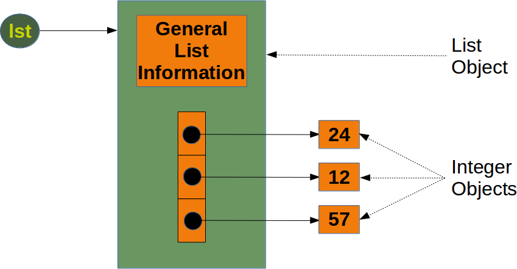

```python
Image(filename="figures/list_structure.png", width=550)
```

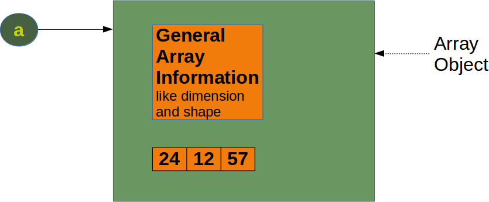

```python
Image(filename="figures/array_structure.png", width=550)
```

```python
# matplotlib 사용하기
import matplotlib.pyplot as plt

# numpy 사용하기
import numpy as np

data1 = [1,2,3,4,5]
arr1 = np.array(data1)
```

```python
data1
```

```
[1, 2, 3, 4, 5]
```

```python
arr1
```

```
array([1, 2, 3, 4, 5])
```

```python
arr1.size
```

```
5
```

```python
arr1.dtype
```

```
dtype('int32')
```

```python
data2 = [1., 2., 3., 3.5, 4.]
data2
```

```
[1.0, 2.0, 3.0, 3.5, 4.0]
```

```python
arr2 = np.array(data2)
arr2.dtype
```

```
dtype('float64')
```

```python
arr4 = np.array([[1,2,3],[4,5,6],[7,8,9],[10,11,12]])
arr4.shape
```

```
(4, 3)
```

```python
np.zeros((3,4))  ## zeros (0.)로 3 x 4 행렬을 초기화,  Float 타입으로 초기화 됨을 유의
```

```
array([[0., 0., 0., 0.],
       [0., 0., 0., 0.],
       [0., 0., 0., 0.]])
```

```python
np.ones((3,4))
```

```
array([[1., 1., 1., 1.],
       [1., 1., 1., 1.],
       [1., 1., 1., 1.]])
```

```python
np.ones((3,4)).dtype
```

```
dtype('float64')
```

```python
np.arange(3,10)
```

```
array([3, 4, 5, 6, 7, 8, 9])
```

```python
arr1 = np.array([[1,2],[3,4]])         # 2 x 2
arr2 = np.array([[1,1],[1,1]])         # 2 x 2
arr3 = np.array([[0,1],[2,3]])         # 2 x 2
```

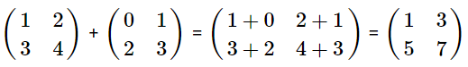

```python
Image(filename="figures/matplus-01.png", width=550)
```

```python
arr1 + arr2  # sum of corresponding elements of matrix
```

```
array([[2, 3],
       [4, 5]])
```

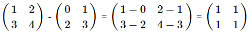

```python
Image(filename="figures/matminus-01.png", width=550)
```

```python
arr1 - arr2  # deduction of corresponding elements of matrix
```

```
array([[0, 1],
       [2, 3]])
```

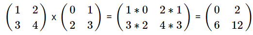

```python
Image(filename="figures/matprod-01.png", width=550)
```

```python
arr1 * arr2
```

```
array([[1, 2],
       [3, 4]])
```

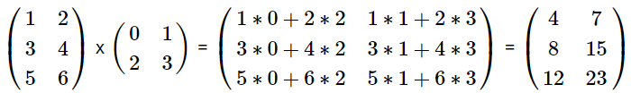

```python
Image(filename="figures/matmul-01.png", width=550)
```

```python
A = np.arange(6).reshape([2,3])
B = np.arange(12).reshape([3,4])
A
```

```
array([[0, 1, 2],
       [3, 4, 5]])
```

```python
B
```

```
array([[ 0,  1,  2,  3],
       [ 4,  5,  6,  7],
       [ 8,  9, 10, 11]])
```

```python
A.dot(B)
```

```
array([[20, 23, 26, 29],
       [56, 68, 80, 92]])
```

```python
np.dot(A,B)
```

```
array([[20, 23, 26, 29],
       [56, 68, 80, 92]])
```

```python
np.matmul(A,B)
```

```
array([[20, 23, 26, 29],
       [56, 68, 80, 92]])
```

#### 일반적으로 행렬(matrix)이란 2차원 구조(행과 열)를 갖는 것을 가리키고,

#### 행렬을 일반화한 것(즉, 3차원, 4차원 등으로 확장한 것)을 텐서(Tensor)라고 함

#### Numpy에서는 텐서 대신에 배열(Array)이라고 부른다.

#### 두 행렬을 곱하는 것을 행렬곱(matrix multiplication)이라 하고,

#### 두 텐서를 곱하는 것을 텐서곱(tensor product)

```python
A = np.arange(2*3*4).reshape((2,3,4))
B2 = np.arange(2*3*4).reshape((2,4,3))
print(A)
print("--------------")
print(B2)
```

```
[[[ 0  1  2  3]
  [ 4  5  6  7]
  [ 8  9 10 11]]

 [[12 13 14 15]
  [16 17 18 19]
  [20 21 22 23]]]
--------------
[[[ 0  1  2]
  [ 3  4  5]
  [ 6  7  8]
  [ 9 10 11]]

 [[12 13 14]
  [15 16 17]
  [18 19 20]
  [21 22 23]]]
```

```python
np.dot(A,B2)
```

```
array([[[[  42,   48,   54],
         [ 114,  120,  126]],

        [[ 114,  136,  158],
         [ 378,  400,  422]],

        [[ 186,  224,  262],
         [ 642,  680,  718]]],


       [[[ 258,  312,  366],
         [ 906,  960, 1014]],

        [[ 330,  400,  470],
         [1170, 1240, 1310]],

        [[ 402,  488,  574],
         [1434, 1520, 1606]]]])
```

```python
np.matmul(A,B2)
```

```
array([[[  42,   48,   54],
        [ 114,  136,  158],
        [ 186,  224,  262]],

       [[ 906,  960, 1014],
        [1170, 1240, 1310],
        [1434, 1520, 1606]]])
```

dot과 matmul차이 https://m.blog.naver.com/cjh226/221356884894 참조 - 반드시 알아두세요!!!

## Produce Random Number depending on normal distribution

```
[-0.29697483 -0.27539804 -0.25382126 -0.23224447 -0.21066769 -0.1890909
 -0.16751412 -0.14593733 -0.12436055 -0.10278376 -0.08120698 -0.05963019
 -0.03805341 -0.01647662  0.00510016  0.02667695  0.04825373  0.06983052
  0.0914073   0.11298409  0.13456087  0.15613766  0.17771444  0.19929123
  0.22086801  0.2424448   0.26402158  0.28559837  0.30717515  0.32875194
  0.35032872]
```

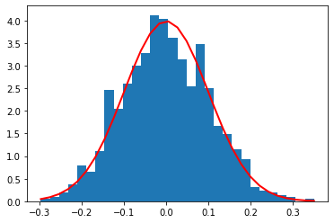

```python
mu, sigma = 0, 0.1
s = np.random.normal(mu, sigma, 1000)
count, bins, ignored = plt.hist(s, 30, normed=True)
print(bins)
plt.plot(bins,
         1/(sigma * np.sqrt(2 * np.pi))  *np.exp( - (bins - mu)**2 / (2 * sigma**2) ),
         linewidth=2,
         color='r')
plt.show()
```

## Min and Max

```python
a = np.array([1,2,3,10,20,30,0.1,0.2])
```

#### Minimum

```python
np.min(a)
```

```
0.1
```

#### Maximum

```python
np.max(a)
```

```
30.0
```

#### Index of array that has the maximum value

```python
np.argmax(a)
```

```
5
```

#### Index of array that has the minium value

```python
np.argmin(a)
```

```
6
```

## numpy.where(condition[, x, y]) -- Find index of array that meets the condition

### When only condition is provided, this function is a shorthand for np.asarray(condition).nonzero(). Using nonzero directly should be preferred, as it behaves correctly for subclasses. The rest of this documentation covers only the case where all three arguments are provided.

Parameters: condition : array_like, bool Where True, yield x, otherwise yield y.

x, y : array_like Values from which to choose. x, y and condition need to be broadcastable to some shape.

Returns:  
out : ndarray An array with elements from x where condition is True, and elements from y elsewhere.

```python
a = np.array([1,2,3,10,20,30,0.1,0.2])
```

```python
np.where(a<1)
```

```
(array([6, 7], dtype=int64),)
```

#### Show the value of array that meets the condition

```python
a = np.array([1,2,3,10,20,30,0.1,0.2])
```

```python
a[np.where(a<1)]
```

```
array([0.1, 0.2])
```

#### Set 0 to values of array that meets conditions

```python
a = np.array([1,2,3,10,20,30,0.1,0.2])
```

```python
np.where(a>=10, 0, a)
```

```
array([1. , 2. , 3. , 0. , 0. , 0. , 0.1, 0.2])
```

#### Set the computation results to the values of array that meets conditions

```python
a = np.array([1,2,3,10,20,30,0.1,0.2])
```

```python
np.where(a>=10, a, a*10)
```

```
array([10., 20., 30., 10., 20., 30.,  1.,  2.])
```

#### Broadcast conditional update of array of matrix

```python
a = np.array([[0, 1, 2], [0, 2, 4],[0, 3, 6]])
```

```python
np.where(a<4, -1, a)
```

```
array([[-1, -1, -1],
       [-1, -1,  4],
       [-1, -1,  6]])
```

```python
x, y = np.ogrid[:3, :5]
x, y
```

```
(array([[0],
        [1],
        [2]]),
 array([[0, 1, 2, 3, 4]]))
```

```python
x, y = np.mgrid[:3, :5]
x, y
```

```
(array([[0, 0, 0, 0, 0],
        [1, 1, 1, 1, 1],
        [2, 2, 2, 2, 2]]),
 array([[0, 1, 2, 3, 4],
        [0, 1, 2, 3, 4],
        [0, 1, 2, 3, 4]]))
```

```python
np.where([[True, False], [True, True]], [[1, 2], [3, 4]], [[9, 8], [7, 6]])
```

```
array([[1, 8],
       [3, 4]])
```

```python
np.ogrid[-1:1:5j]
```

```
array([-1. , -0.5,  0. ,  0.5,  1. ])
```